# Health Insurance Claims Analysis

## Insurance Data Analysis

```python
#import system
import os
import sys
import warnings
warnings.filterwarnings('ignore')
#import libraries
import pandas as pd
%matplotlib inline
import matplotlib.pyplot as plt
import seaborn as sns
import numpy as np
import statsmodels.api as sm
```

### Import Data

```python
#import datasets
insurance_data = pd.read_csv('insurance_data.csv', index_col=0)

#check data
insurance_data .info()

#inspect dataset
insurance_data.head()
```

```
<class 'pandas.core.frame.DataFrame'>
Index: 1340 entries, 0 to 1339
Data columns (total 10 columns):
 #   Column         Non-Null Count  Dtype
---  ------         --------------  -----
 0   PatientID      1340 non-null   int64
 1   age            1335 non-null   float64
 2   gender         1340 non-null   object
 3   bmi            1340 non-null   float64
 4   bloodpressure  1340 non-null   int64
 5   diabetic       1340 non-null   object
 6   children       1340 non-null   int64
 7   smoker         1340 non-null   object
 8   region         1337 non-null   object
 9   claim          1340 non-null   float64
dtypes: float64(3), int64(3), object(4)
memory usage: 115.2+ KB
```

| index | PatientID | age | gender | bmi | bloodpressure | diabetic | children | smoker | region | claim |
| --- | --- | --- | --- | --- | --- | --- | --- | --- | --- | --- |
| 0 | 1 | 39.0 | male | 23.2 | 91 | Yes | 0 | No | southeast | 1121.87 |
| 1 | 2 | 24.0 | male | 30.1 | 87 | No | 0 | No | southeast | 1131.51 |
| 2 | 3 | NaN | male | 33.3 | 82 | Yes | 0 | No | southeast | 1135.94 |
| 3 | 4 | NaN | male | 33.7 | 80 | No | 0 | No | northwest | 1136.40 |
| 4 | 5 | NaN | male | 34.1 | 100 | No | 0 | No | northwest | 1137.01 |

### Explore the Data

```python
#check for missing data
insurance_data .isnull().sum()
```

```
PatientID        0
age              5
gender           0
bmi              0
bloodpressure    0
diabetic         0
children         0
smoker           0
region           3
claim            0
dtype: int64
```

5 clients have no age, 3 no region

```python
#explore numeric variables
insurance_data.describe().round(2).T
```

|  | count | mean | std | min | 25% | 50% | 75% | max |
| --- | --- | --- | --- | --- | --- | --- | --- | --- |
| PatientID | 1340.0 | 670.50 | 386.97 | 1.00 | 335.75 | 670.50 | 1005.25 | 1340.00 |
| age | 1335.0 | 38.08 | 11.10 | 18.00 | 29.00 | 38.00 | 47.00 | 60.00 |
| bmi | 1340.0 | 30.67 | 6.11 | 16.00 | 26.28 | 30.40 | 34.70 | 53.10 |
| bloodpressure | 1340.0 | 94.16 | 11.43 | 80.00 | 86.00 | 92.00 | 99.00 | 140.00 |
| children | 1340.0 | 1.09 | 1.21 | 0.00 | 0.00 | 1.00 | 2.00 | 5.00 |
| claim | 1340.0 | 13252.75 | 12109.61 | 1121.87 | 4719.68 | 9369.62 | 16604.30 | 63770.43 |

Mean age=38, min=18, max=60

Mean bp = 94.16, min=80, max=140

mean claim 13252.75, min=1121.87, max=63770.43

```python
insurance_data.columns
```

```
Index(['PatientID', 'age', 'gender', 'bmi', 'bloodpressure', 'diabetic',
       'children', 'smoker', 'region', 'claim'],
      dtype='object')
```

```python
# check value counts of categorical columns
column=['gender', 'diabetic', 'children', 'region']
for col in column:
    insurance_data.value_counts(col)
print(col)
```

```
gender
male      678
female    662
Name: count, dtype: int64
```

```
diabetic
No     698
Yes    642
Name: count, dtype: int64
```

```
children
0    576
1    324
2    240
3    157
4     25
5     18
Name: count, dtype: int64
```

```
region
southeast    443
northwest    349
southwest    314
northeast    231
Name: count, dtype: int64
```

```
region
```

### Data Cleaning

```python
#Fill missing values for age by mean & region by most frequent region
insurance_data['age'].fillna(38, inplace=True)
insurance_data['region'].fillna('southeast', inplace=True)
```

### EDA

```python
#list variable groups
numerical_vars = [
  'age', 'bmi', 'bloodpressure', 'children', 'claim']

categorical_vars = [
  'gender', 'diabetic', 'smoker', 'region']
#check data
data= insurance_data[numerical_vars + categorical_vars]
data.shape
```

```
(1340, 9)
```

#### Distribution of Numerical variables

```python
sns.set(style='whitegrid', palette="deep", font_scale=1.1, rc={"figure.figsize": [10, 5]})

# Define your parameters
params = {
    'figure.figsize': (8, 4),  # Set the figure size (width, height)
    'font.size': 12,            # Set the font size
    'axes.labelsize': 12,       # Set the label size
    'axes.titlesize': 12,       # Set the title size
    'axes.titleweight': 'bold',  # Set the title font weight
    'axes.titlepad': 20,           # Set the distance between the title and the plot
    'xtick.labelsize': 12,      # Set the x-axis tick label size
    'ytick.labelsize': 12,      # Set the y-axis tick label size
    'xtick.direction': 'inout',  #set xtick direction
    'legend.fontsize': 12,      # set legend font size
    'legend.title_fontsize': 12     # Set the legend title font size

    }
```

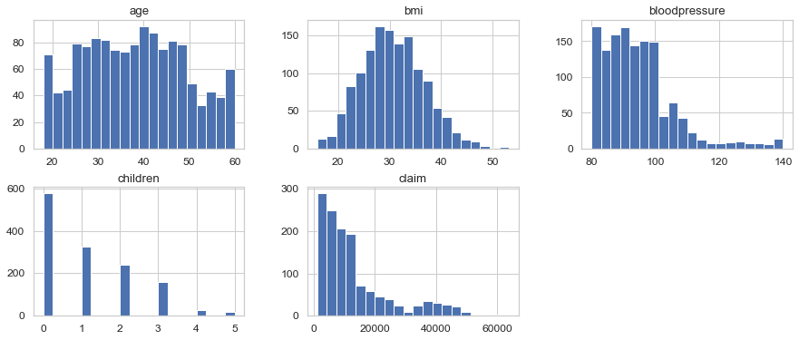

```python
#distribution of numeric variables
data[numerical_vars].hist(bins=20, figsize=(15, 6), layout=(2, 3));
```

BMI seems normally distributed.

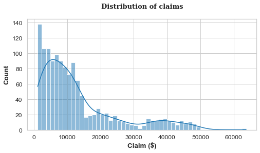

```python
# Apply plot parameters
plt.rcParams.update(params)

sns.set(style='whitegrid', palette="tab10", font_scale=1.1, rc={"figure.figsize": [8, 4]})

sns.histplot(data=data, x='claim', bins=50, kde=True)
plt.title('Distribution of claims', fontsize=13, fontfamily='serif')
plt.xlabel('Claim ($)', fontweight='bold')
plt.ylabel('Count', fontweight='bold')
plt.grid(True)

plt.show();
```

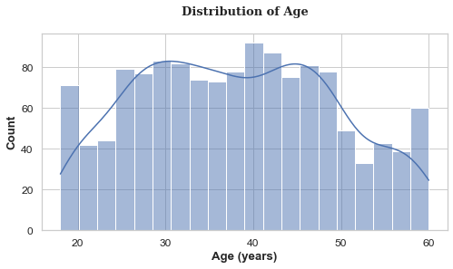

```python
# Apply plot parameters
plt.rcParams.update(params)

sns.set(style='whitegrid', palette="deep", font_scale=1.1, rc={"figure.figsize": [8, 4]})
sns.histplot(data=data, x='age', bins=20, kde=True, palette='Set2')
plt.title('Distribution of Age', fontsize=13, fontfamily='serif')
plt.xlabel('Age (years)', fontweight='bold')
plt.ylabel('Count', fontweight='bold')
plt.grid(True)

plt.show();
```

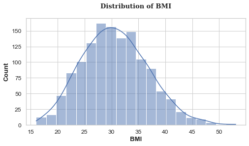

```python
# Apply plot parameters
plt.rcParams.update(params)

sns.set(style='whitegrid', palette="deep", font_scale=1.1, rc={"figure.figsize": [8, 4]})
sns.histplot(data=data, x='bmi', bins=20, kde=True, palette='Set2')
plt.title('Distribution of BMI', fontsize=13, fontfamily='serif')
plt.xlabel('BMI', fontweight='bold')
plt.ylabel('Count', fontweight='bold')
plt.grid(True)

plt.show();
```

#### Distribution of Categorical variables

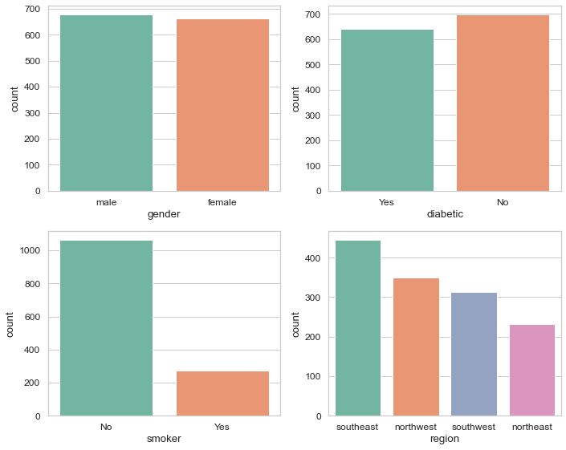

```python
fig, ax = plt.subplots(2, 2, figsize=(10, 8))
for variable, subplot in zip(categorical_vars, ax.flatten()):
    sns.countplot(x=data[variable], ax=subplot, palette = "Set2")
    for label in subplot.get_xticklabels():
        label.set_rotation(0)

plt.tight_layout()  # Adjust subplots to fit into figure area.
plt.show();
```

There are almost equal numbers of men and women. Many people are non smokers. Northeast has the least number of claims.

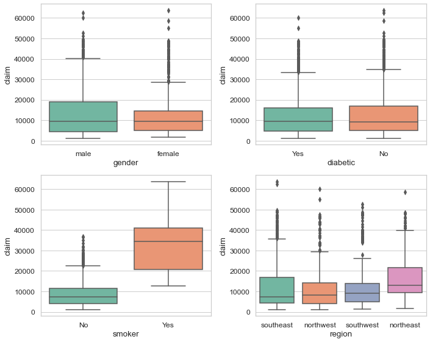

```python
#explore claims by categorical variables
fig, ax = plt.subplots(2, 2, figsize=(10, 8))

palette = sns.color_palette("Set2")
for var, subplot in zip(categorical_vars, ax.flatten()):
    sns.boxplot(x=var, y='claim', data=data, ax=subplot, palette=palette);

plt.tight_layout()  # Adjust subplots to fit into figure area.
plt.show();
```

Median claim amounts are quite similar for men and women. However the claims vary more in men than women.

The distribution of claims is similar between diabetics and non diabetics

There is a clear difference in claims between smokers and non smokers. Smokers have higher claims (costs more money)

The median claims vary between the regions. The northeast have higher claims among the regions.

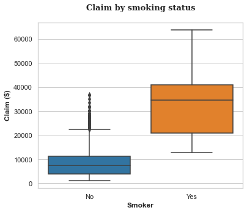

```python
# Apply plot parameters
plt.rcParams.update(params)

#plot showing distributin of claims by smoking status
sns.set(style='whitegrid')
plt.figure(figsize=(6,5))
sns.boxplot(x="smoker",
                y="claim",
                data=data, palette='tab10')
plt.title('Claim by smoking status', fontsize=13, fontfamily='serif')
plt.ylabel('Claim ($)', fontweight='bold')
plt.xlabel('Smoker', fontweight='bold')

plt.show();
```

there are more smokers in Southeast compared to other regions.

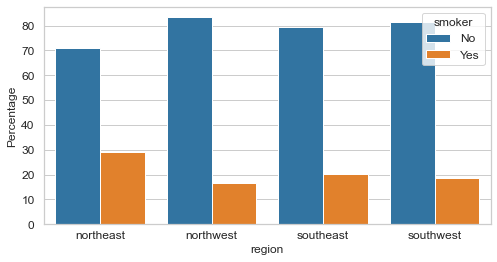

```python
# Actual counts based on your data
counts = data.groupby(['region', 'smoker']).size().unstack(fill_value=0)

# Normalize the counts to get percentages
percentages = counts.div(counts.sum(axis=1), axis=0) * 100

# Reset index and melt the DataFrame to long format
percentages = percentages.reset_index().melt(id_vars='region', value_vars=percentages.columns,
                                             var_name='smoker', value_name='percentage')

# Apply plot parameters
plt.rcParams.update(params)

# Create the bar plot
plt.figure(figsize=(8, 4))
ax = sns.barplot(x='region', y='percentage', hue='smoker', data=percentages, palette="tab10")

# Set the y-axis label to "Percentage"
ax.set_ylabel("Percentage")

# Show the plot
plt.show();
```

Northeast has a higher proportion of smokers.

```python
data.groupby('region')['smoker'].value_counts()
```

```
region     smoker
northeast  No        164
           Yes        67
northwest  No        291
           Yes        58
southeast  No        355
           Yes        91
southwest  No        256
           Yes        58
Name: count, dtype: int64
```

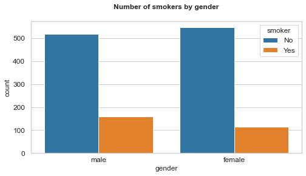

```python
#number of smokers by gender
# Apply plot parameters
plt.rcParams.update(params)

sns.countplot(x = 'gender', hue='smoker', data = insurance_data, palette = "tab10")
plt.title('Number of smokers by gender')
plt.show();
```

There are more male smokers compared to female smokers.

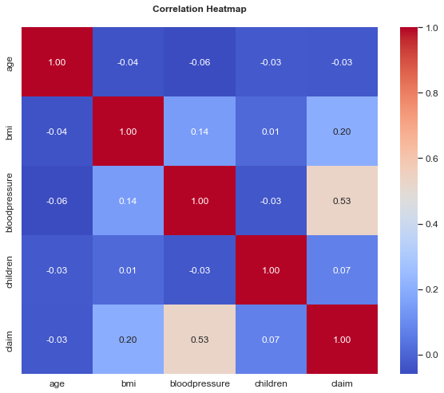

```python
#check correlation between variables
numeric_df = data.select_dtypes(include=[np.number])

# Compute the correlation matrix
corr_matrix = numeric_df.corr()

# Plot the heatmap
plt.figure(figsize=(10, 8))
sns.heatmap(corr_matrix, annot=True, cmap='coolwarm', fmt='.2f')
plt.title('Correlation Heatmap')
plt.show();
```

The variables do not show any correlations to each other. Only bloodpressure shows some relationship to claim.

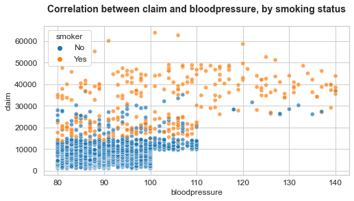

```python
# Scatterplot with Hue & Size, bp and smoker
sns.scatterplot(data=data, x='bloodpressure', y='claim', sizes=(40, 400), alpha=.7,
              palette='tab10', hue='smoker')
plt.title('Correlation between claim and bloodpressure, by smoking status', fontsize=14)
plt.show();
```

The scatter plot shows high claims by smokers. Bloodpressure maynot be an indicator of claim amount but smoking status could be.

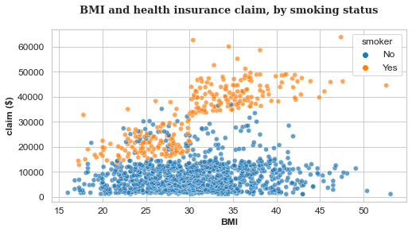

```python
#explore relationships between smker, bmi and claim
# Apply plot parameters
plt.rcParams.update(params)

# Scatterplot with Hue & Size
sns.scatterplot(data=data, x='bmi', y='claim', sizes=(40, 400), alpha=.7,
              palette='tab10', hue='smoker')
plt.title('BMI and health insurance claim, by smoking status', fontsize=13, fontfamily='serif')
plt.ylabel("claim ($)", fontweight='bold')
plt.xlabel("BMI", fontweight='bold')

plt.show();
```

The plot shows a correlation between bmi and claim by smoking status.

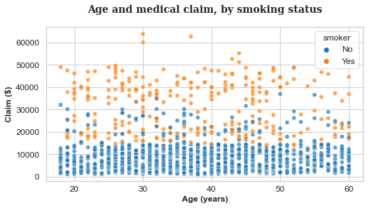

```python
# Apply plot parameters
plt.rcParams.update(params)

# Scatterplot with Hue & Size
sns.scatterplot(data=data, x='age', y='claim', sizes=(40, 400), alpha=.7,
              palette='tab10', hue='smoker')
plt.title('Age and medical claim, by smoking status', fontsize=14, fontfamily='serif')
plt.ylabel("Claim ($)", fontweight='bold')
plt.xlabel("Age (years)", fontweight='bold')
plt.show();
```

### Model development

How much does smoking influence claims

What other factors impact the claims made by clients?

```python
# Convert 'gender' column to dummy variables
x = pd.get_dummies(data['smoker'], drop_first=True)
x = x.astype(int)
# Inspect the resulting DataFrame
print(x.head(3))
```

```
       Yes
index
0        0
1        0
2        0
```

##### Model 1

```python
# Add a constant term to the predictors
x = sm.add_constant(x)

# Define the dependent variable
y = data['claim']

# Fit the OLS regression model
model = sm.OLS(y, x).fit()

# Make predictions
predictions = model.predict(x)

# Get the summary of the model
summary = model.summary()
print(summary)
```

```
                            OLS Regression Results
==============================================================================
Dep. Variable:                  claim   R-squared:                       0.620
Model:                            OLS   Adj. R-squared:                  0.620
Method:                 Least Squares   F-statistic:                     2181.
Date:                Thu, 01 Aug 2024   Prob (F-statistic):          2.91e-283
Time:                        10:58:02   Log-Likelihood:                -13851.
No. Observations:                1340   AIC:                         2.771e+04
Df Residuals:                    1338   BIC:                         2.772e+04
Df Model:                           1
Covariance Type:            nonrobust
==============================================================================
                 coef    std err          t      P>|t|      [0.025      0.975]
------------------------------------------------------------------------------
const       8421.1216    228.779     36.809      0.000    7972.318    8869.925
Yes         2.363e+04    505.933     46.704      0.000    2.26e+04    2.46e+04
==============================================================================
Omnibus:                      136.350   Durbin-Watson:                   0.995
Prob(Omnibus):                  0.000   Jarque-Bera (JB):              212.810
Skew:                           0.728   Prob(JB):                     6.15e-47
Kurtosis:                       4.301   Cond. No.                         2.60
==============================================================================

Notes:
[1] Standard Errors assume that the covariance matrix of the errors is correctly specified.
```

An R-squared value of 0.620 means that 62.0% of the variance in the claim variable is explained by the independent variables included in the model (smoker). This implies that the model explains a significant portion of the variability in the claim data, but not all of it. Model Fit:

An R-squared of 0.620 suggests a reasonably good fit, indicating that the model is fairly effective in capturing the relationship between the independent variables and the dependent variable. However, it also indicates that 38.0% of the variance in claim is not explained by the model, suggesting there may be other factors influencing claim that are not included in the model.

From the model: going from a non smoker to a smoker, the claim amount increases by $23,630

##### Model 2

```python
# Convert 'children' to categorical and create dummy variables
data['children'] = data['children'].astype(str)
children_dummies = pd.get_dummies(data['children'], prefix='children', drop_first=True)

# Convert other categorical variables to dummy variables
categorical_vars = ['gender', 'diabetic', 'smoker', 'region']
categorical_dummies = pd.get_dummies(data[categorical_vars], drop_first=True)

# Ensure dummy variables are integers (0 and 1) instead of booleans (True and False)
categorical_dummies = categorical_dummies.astype(int)
children_dummies = children_dummies.astype(int)

# Combine continuous variables with dummy variables
continuous_vars = data[['age', 'bloodpressure', 'bmi']]
x = pd.concat([continuous_vars, children_dummies, categorical_dummies], axis=1)

# Add the constant term to the predictors
x = sm.add_constant(x)

# Define the dependent variable
y = data['claim']

# Fit the OLS regression model
model = sm.OLS(y, x).fit()

# Make predictions
predictions = model.predict(x)

# Get the summary of the model
summary = model.summary()
print(summary)
```

```
                            OLS Regression Results
==============================================================================
Dep. Variable:                  claim   R-squared:                       0.708
Model:                            OLS   Adj. R-squared:                  0.705
Method:                 Least Squares   F-statistic:                     229.4
Date:                Thu, 01 Aug 2024   Prob (F-statistic):               0.00
Time:                        10:58:02   Log-Likelihood:                -13675.
No. Observations:                1340   AIC:                         2.738e+04
Df Residuals:                    1325   BIC:                         2.746e+04
Df Model:                          14
Covariance Type:            nonrobust
====================================================================================
                       coef    std err          t      P>|t|      [0.025      0.975]
------------------------------------------------------------------------------------
const             -2.25e+04   2026.723    -11.102      0.000   -2.65e+04   -1.85e+04
age                 17.9963     17.735      1.015      0.310     -16.795      52.788
bloodpressure      229.2425     17.622     13.009      0.000     194.672     263.813
bmi                347.0946     30.653     11.323      0.000     286.961     407.228
children_1         558.6524    457.627      1.221      0.222    -339.099    1456.404
children_2        1965.4971    506.238      3.883      0.000     972.381    2958.613
children_3        2231.8951    593.860      3.758      0.000    1066.887    3396.903
children_4        2954.8003   1346.306      2.195      0.028     313.676    5595.925
children_5        1172.5625   1583.505      0.740      0.459   -1933.887    4279.012
gender_male        -62.8134    393.358     -0.160      0.873    -834.485     708.858
diabetic_Yes      -320.2736    361.395     -0.886      0.376   -1029.243     388.696
smoker_Yes        2.066e+04    496.473     41.615      0.000    1.97e+04    2.16e+04
region_northwest -2074.6541    562.646     -3.687      0.000   -3178.428    -970.880
region_southeast -2901.6197    543.873     -5.335      0.000   -3968.566   -1834.673
region_southwest -2198.8364    575.757     -3.819      0.000   -3328.330   -1069.342
==============================================================================
Omnibus:                      217.448   Durbin-Watson:                   1.252
Prob(Omnibus):                  0.000   Jarque-Bera (JB):              420.421
Skew:                           0.973   Prob(JB):                     5.09e-92
Kurtosis:                       4.934   Cond. No.                     1.22e+03
==============================================================================

Notes:
[1] Standard Errors assume that the covariance matrix of the errors is correctly specified.
[2] The condition number is large, 1.22e+03. This might indicate that there are
strong multicollinearity or other numerical problems.
```

Our model has a high condition number ?multicollinearity. I dont think its multicolinearity as our correlation matrix did not show correlation between variables. We will try centering the contnous variables and see what happens.

```python
#create function to center continous data
center_function = lambda x: x - x.mean()

#apply function to original NumPy array
data_centered = center_function(continuous_vars)
print(data_centered)
```

```
             age  bloodpressure        bmi
index
0       0.921642      -3.157463  -7.468955
1     -14.078358      -7.157463  -0.568955
2      -0.078358     -12.157463   2.631045
3      -0.078358     -14.157463   3.031045
4      -0.078358       5.842537   3.431045
...          ...            ...        ...
1335    5.921642      -6.157463   4.831045
1336   20.921642      25.842537   7.431045
1337   -8.078358      -3.157463   3.831045
1338   -1.078358      11.842537  -0.268955
1339   -8.078358       6.842537  16.731045

[1340 rows x 3 columns]
```

```python
# Convert 'children' to categorical and create dummy variables
data['children'] = data['children'].astype(str)
children_dummies = pd.get_dummies(data['children'], prefix='children', drop_first=True)

# Convert other categorical variables to dummy variables
categorical_vars = ['gender', 'diabetic', 'smoker', 'region']
categorical_dummies = pd.get_dummies(data[categorical_vars], drop_first=True)

# Ensure dummy variables are integers (0 and 1) instead of booleans (True and False)
categorical_dummies = categorical_dummies.astype(int)
children_dummies = children_dummies.astype(int)

x = pd.concat([data_centered, children_dummies, categorical_dummies], axis=1)

# Add the constant term to the predictors
x = sm.add_constant(x)

# Define the dependent variable
y = data['claim']

# Fit the OLS regression model
model = sm.OLS(y, x).fit()

# Make predictions
predictions = model.predict(x)

# Get the summary of the model
summary = model.summary()
print(summary)
```

```
                            OLS Regression Results
==============================================================================
Dep. Variable:                  claim   R-squared:                       0.708
Model:                            OLS   Adj. R-squared:                  0.705
Method:                 Least Squares   F-statistic:                     229.4
Date:                Thu, 01 Aug 2024   Prob (F-statistic):               0.00
Time:                        10:58:02   Log-Likelihood:                -13675.
No. Observations:                1340   AIC:                         2.738e+04
Df Residuals:                    1325   BIC:                         2.746e+04
Df Model:                          14
Covariance Type:            nonrobust
====================================================================================
                       coef    std err          t      P>|t|      [0.025      0.975]
------------------------------------------------------------------------------------
const             1.042e+04    566.554     18.383      0.000    9303.694    1.15e+04
age                 17.9963     17.735      1.015      0.310     -16.795      52.788
bloodpressure      229.2425     17.622     13.009      0.000     194.672     263.813
bmi                347.0946     30.653     11.323      0.000     286.961     407.228
children_1         558.6524    457.627      1.221      0.222    -339.099    1456.404
children_2        1965.4971    506.238      3.883      0.000     972.381    2958.613
children_3        2231.8951    593.860      3.758      0.000    1066.887    3396.903
children_4        2954.8003   1346.306      2.195      0.028     313.676    5595.925
children_5        1172.5625   1583.505      0.740      0.459   -1933.887    4279.012
gender_male        -62.8134    393.358     -0.160      0.873    -834.485     708.858
diabetic_Yes      -320.2736    361.395     -0.886      0.376   -1029.243     388.696
smoker_Yes        2.066e+04    496.473     41.615      0.000    1.97e+04    2.16e+04
region_northwest -2074.6541    562.646     -3.687      0.000   -3178.428    -970.880
region_southeast -2901.6197    543.873     -5.335      0.000   -3968.566   -1834.673
region_southwest -2198.8364    575.757     -3.819      0.000   -3328.330   -1069.342
==============================================================================
Omnibus:                      217.448   Durbin-Watson:                   1.252
Prob(Omnibus):                  0.000   Jarque-Bera (JB):              420.421
Skew:                           0.973   Prob(JB):                     5.09e-92
Kurtosis:                       4.934   Cond. No.                         103.
==============================================================================

Notes:
[1] Standard Errors assume that the covariance matrix of the errors is correctly specified.
```

Age, gender and diabetic are not significant variables in the model. We will drop them from the model.

##### Model 3

```python
# Convert 'children' to categorical and create dummy variables
data['children'] = data['children'].astype(str)
children_dummies = pd.get_dummies(data['children'], prefix='children', drop_first=True)

# Convert other categorical variables to dummy variables
categorical_vars = [ 'smoker', 'region']
categorical_dummies = pd.get_dummies(data[categorical_vars], drop_first=True)

# Ensure dummy variables are integers (0 and 1) instead of booleans (True and False)
categorical_dummies = categorical_dummies.astype(int)
children_dummies = children_dummies.astype(int)

# Combine continuous variables with dummy variables
continuous_vars2 = data_centered[['bloodpressure', 'bmi']]
x = pd.concat([continuous_vars2, children_dummies, categorical_dummies], axis=1)

# Add the constant term to the predictors
x = sm.add_constant(x)

# Define the dependent variable
y = data['claim']

# Fit the OLS regression model
model = sm.OLS(y, x).fit()

# Make predictions
predictions = model.predict(x)

# Get the summary of the model
summary = model.summary()
print(summary)
```

```
                            OLS Regression Results
==============================================================================
Dep. Variable:                  claim   R-squared:                       0.707
Model:                            OLS   Adj. R-squared:                  0.705
Method:                 Least Squares   F-statistic:                     291.9
Date:                Thu, 01 Aug 2024   Prob (F-statistic):               0.00
Time:                        10:58:02   Log-Likelihood:                -13676.
No. Observations:                1340   AIC:                         2.738e+04
Df Residuals:                    1328   BIC:                         2.744e+04
Df Model:                          11
Covariance Type:            nonrobust
====================================================================================
                       coef    std err          t      P>|t|      [0.025      0.975]
------------------------------------------------------------------------------------
const             1.022e+04    495.639     20.618      0.000    9246.948    1.12e+04
bloodpressure      228.6910     17.571     13.015      0.000     194.222     263.160
bmi                346.4671     30.565     11.335      0.000     286.506     406.428
children_1         577.5108    457.098      1.263      0.207    -319.202    1474.224
children_2        1946.4684    505.852      3.848      0.000     954.113    2938.824
children_3        2221.1996    593.406      3.743      0.000    1057.084    3385.315
children_4        2976.2870   1345.328      2.212      0.027     337.087    5615.487
children_5        1182.5366   1582.246      0.747      0.455   -1921.437    4286.510
smoker_Yes        2.064e+04    494.403     41.751      0.000    1.97e+04    2.16e+04
region_northwest -2060.6608    561.732     -3.668      0.000   -3162.640    -958.682
region_southeast -2882.1538    543.546     -5.302      0.000   -3948.457   -1815.851
region_southwest -2181.9306    575.045     -3.794      0.000   -3310.027   -1053.835
==============================================================================
Omnibus:                      216.983   Durbin-Watson:                   1.249
Prob(Omnibus):                  0.000   Jarque-Bera (JB):              417.804
Skew:                           0.973   Prob(JB):                     1.88e-91
Kurtosis:                       4.922   Cond. No.                         102.
==============================================================================

Notes:
[1] Standard Errors assume that the covariance matrix of the errors is correctly specified.
```

After dropping age, gender and diabetic, the model hasnot changed. R2 = 70.7%. so we will keep these values.

Now lets check if we can increase the R2 by an interraction between smoking and BMI

##### Model 4

```python
# Convert 'children' to categorical and create dummy variables
data['children'] = data['children'].astype(str)
children_dummies = pd.get_dummies(data['children'], prefix='children', drop_first=True)

# Convert other categorical variables to dummy variables
categorical_vars = ['smoker', 'region']
categorical_dummies = pd.get_dummies(data[categorical_vars], drop_first=True)

# Ensure dummy variables are integers (0 and 1) instead of booleans (True and False)
categorical_dummies = categorical_dummies.astype(int)
children_dummies = children_dummies.astype(int)

# Combine continuous variables with dummy variables
x = pd.concat([continuous_vars2, children_dummies, categorical_dummies], axis=1)

# Create the interaction term between bmi and smoker
x['bmi_smoker'] = x['bmi'] * x['smoker_Yes']  # assuming the smoker dummy variable is named 'smoker_yes'

# Add the constant term to the predictors
x = sm.add_constant(x)

# Define the dependent variable
y = data['claim']

# Fit the OLS regression model with the interaction term
model_interaction = sm.OLS(y, x).fit()

# Make predictions
predictions_interaction = model_interaction.predict(x)

# Get the summary of the model
summary_interaction = model_interaction.summary()
print(summary_interaction)
```

```
                            OLS Regression Results
==============================================================================
Dep. Variable:                  claim   R-squared:                       0.775
Model:                            OLS   Adj. R-squared:                  0.773
Method:                 Least Squares   F-statistic:                     381.2
Date:                Thu, 01 Aug 2024   Prob (F-statistic):               0.00
Time:                        10:58:02   Log-Likelihood:                -13499.
No. Observations:                1340   AIC:                         2.702e+04
Df Residuals:                    1327   BIC:                         2.709e+04
Df Model:                          12
Covariance Type:            nonrobust
====================================================================================
                       coef    std err          t      P>|t|      [0.025      0.975]
------------------------------------------------------------------------------------
const             1.057e+04    435.055     24.304      0.000    9720.052    1.14e+04
bloodpressure      159.6602     15.792     10.110      0.000     128.679     190.641
bmi                 89.8499     29.723      3.023      0.003      31.541     148.159
children_1         548.8201    400.895      1.369      0.171    -237.636    1335.277
children_2        1862.7360    443.671      4.198      0.000     992.364    2733.108
children_3        2180.2595    520.443      4.189      0.000    1159.278    3201.241
children_4        3298.1713   1180.013      2.795      0.005     983.277    5613.066
children_5        1658.6590   1387.893      1.195      0.232   -1064.045    4381.363
smoker_Yes        2.138e+04    435.173     49.127      0.000    2.05e+04    2.22e+04
region_northwest -2633.7493    493.494     -5.337      0.000   -3601.862   -1665.636
region_southeast -3562.3300    477.923     -7.454      0.000   -4499.898   -2624.762
region_southwest -2721.7127    505.059     -5.389      0.000   -3712.513   -1730.912
bmi_smoker        1282.9138     64.187     19.987      0.000    1156.994    1408.833
==============================================================================
Omnibus:                      352.725   Durbin-Watson:                   1.197
Prob(Omnibus):                  0.000   Jarque-Bera (JB):              962.663
Skew:                           1.358   Prob(JB):                    9.13e-210
Kurtosis:                       6.141   Cond. No.                         102.
==============================================================================

Notes:
[1] Standard Errors assume that the covariance matrix of the errors is correctly specified.
```

```python
# Extract and round coefficients
coefficients = model_interaction.params.round(2)
print(coefficients)
```

```
const               10573.52
bloodpressure         159.66
bmi                    89.85
children_1            548.82
children_2           1862.74
children_3           2180.26
children_4           3298.17
children_5           1658.66
smoker_Yes          21378.60
region_northwest    -2633.75
region_southeast    -3562.33
region_southwest    -2721.71
bmi_smoker           1282.91
dtype: float64
```

The interraction between smoking and BMI has increased our adjusted R2 to 0.773. The final model explains 77.3% of the variation in Claims.

Smokers have claims that are 21,380 dollars higher than non-smokers, when BMI is at its mean (30.67) and other variables are held constant.

The interaction term between BMI and being a smoker indicates that the effect of BMI on claims is significantly higher for smokers compared to non-smokers. Specifically, for each one-unit increase in BMI, the increase in claims for smokers is 1,282.91 dollars higher than for non-smokers.

### Model plots

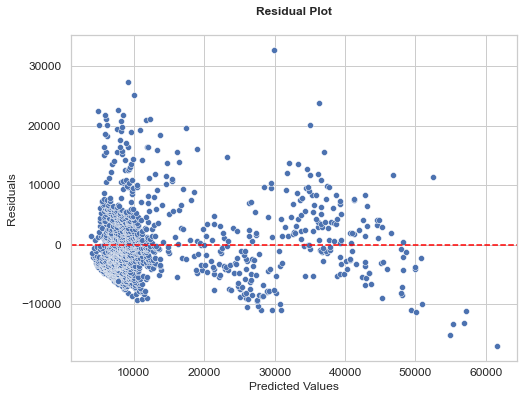

```python
# Residuals from the model
residuals = model_interaction.resid

# Plotting residuals
plt.figure(figsize=(8, 6))
sns.scatterplot(x=predictions_interaction, y=residuals)
plt.axhline(0, color='red', linestyle='--')
plt.title('Residual Plot')
plt.xlabel('Predicted Values')
plt.ylabel('Residuals')
plt.show();
```

#### Predicted Vs Actual

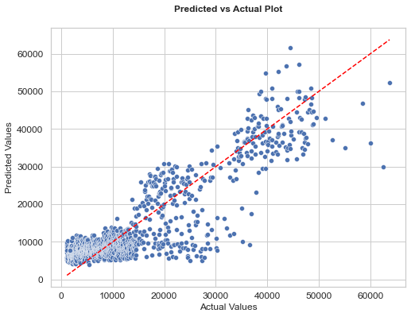

```python
plt.figure(figsize=(8, 6))
sns.scatterplot(x=y, y=predictions_interaction)
plt.plot([y.min(), y.max()], [y.min(), y.max()], linestyle='--', color='red')
plt.title('Predicted vs Actual Plot')
plt.xlabel('Actual Values')
plt.ylabel('Predicted Values')
plt.show();
```

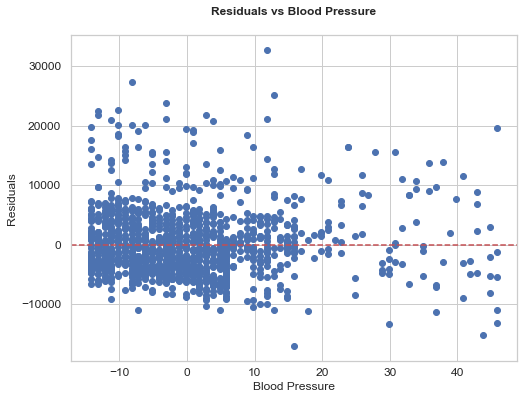

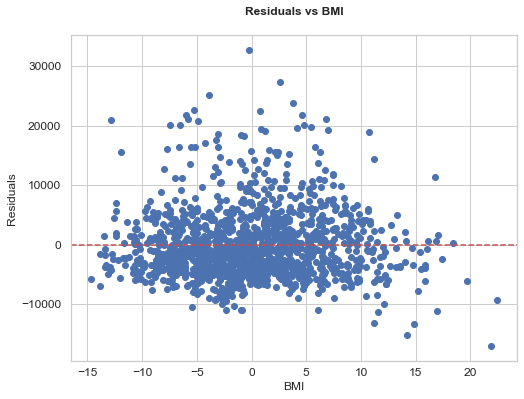

```python
# Plotting residuals vs. bloodpressure
plt.figure(figsize=(8, 6))
plt.scatter(x['bloodpressure'], residuals)
plt.axhline(y=0, color='r', linestyle='--')
plt.xlabel('Blood Pressure')
plt.ylabel('Residuals')
plt.title('Residuals vs Blood Pressure')
plt.show()

# Plotting residuals vs. bmi
plt.figure(figsize=(8, 6))
plt.scatter(x['bmi'], residuals)
plt.axhline(y=0, color='r', linestyle='--')
plt.xlabel('BMI')
plt.ylabel('Residuals')
plt.title('Residuals vs BMI')
plt.show();
```

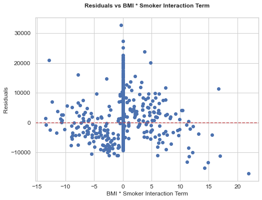

```python
# Plotting residuals vs. interaction term (bmi * smoker)
plt.figure(figsize=(8, 6))
plt.scatter(x['bmi_smoker'], residuals)
plt.axhline(y=0, color='r', linestyle='--')
plt.xlabel('BMI * Smoker Interaction Term')
plt.ylabel('Residuals')
plt.title('Residuals vs BMI * Smoker Interaction Term')
plt.show();
```

We would need to work on outliers to refine our model. But the overall picture is shown below

#### Model with interraction

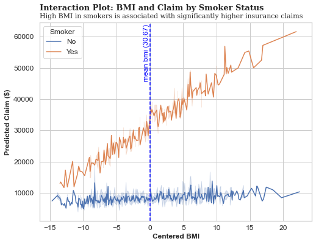

```python
# Apply plot parameters
plt.rcParams.update(params)

# Example assuming 'bmi' and 'claim' are continuous variables
plt.figure(figsize=(8, 6))
sns.lineplot(x=x['bmi'], y=predictions_interaction, hue=x['smoker_Yes'])
plt.title('Interaction Plot: BMI and Claim by Smoker Status', fontsize=13, fontfamily='serif', loc='left')
plt.xlabel('Centered BMI', fontweight='bold')
plt.ylabel('Predicted Claim ($)', fontweight='bold')
plt.suptitle('High BMI in smokers is associated with significantly higher insurance claims',
             fontsize=11, fontfamily='serif', y=0.915)

# Add vertical line for mean BMI
mean_bmi = 0
plt.axvline(x=mean_bmi, color='#ADD8E6', linestyle='--', linewidth=0.5, label='Mean BMI (30.67)')

# Add vertical line for mean BMI
mean_bmi = 0
plt.axvline(x=mean_bmi, color='blue', linestyle='--', label='Mean BMI (30.67)')

# Label the vertical line
plt.text(mean_bmi - 0.5, plt.ylim()[1] * 0.85,
         'mean bmi (30.67)', rotation=90, ha='center', va='center', color='blue')

#legend placement
handles, labels = plt.gca().get_legend_handles_labels()
new_labels = ['No', 'Yes']
plt.legend(handles=handles, labels=new_labels, title='Smoker')

plt.show();
```

Blue Line (Non smoker): This line shows the predicted insurance claims for non-smokers across different BMI values. Orange Line (Smoker): This line shows the predicted insurance claims for smokers across different BMI values.

- Trend for Smokers:

There is a clear upward trend in predicted claims as BMI increases. This indicates that for smokers, higher BMI is associated with significantly higher insurance claims. The orange line's steep slope suggests that the effect of BMI on insurance claims is much more pronounced for smokers. Trend for Non-Smokers:

- The blue line remains relatively flat with a slight increase as BMI increases, indicating that BMI has a lesser impact on predicted claims for non-smokers compared to smokers. The variability in predicted claims for non-smokers is much lower compared to smokers. Interaction Effect:

The significant gap between the orange and blue lines across all BMI values suggests a strong interaction effect between BMI and smoking status. Smokers with higher BMI have disproportionately higher insurance claims compared to non-smokers with similar BMI.

### whats happening in the regions??

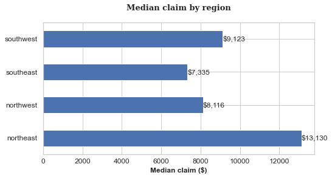

```python
# Calculate median claims by region
median_claims_by_region = data.groupby('region')['claim'].median()

# Create a horizontal bar plot
ax = median_claims_by_region.plot(kind='barh', figsize=(8, 4))

# Set title and labels
plt.title('Median claim by region', fontsize=13, fontfamily='serif')
plt.xlabel('Median claim ($)', fontweight='bold')
plt.ylabel('')

# Annotate bars
for index, value in enumerate(median_claims_by_region):
    ax.text(value, index, f'${value:,.0f}', va='center')

# Show the plot
plt.show();
```

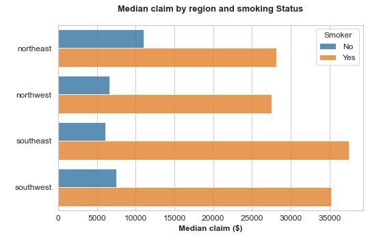

```python
# group by 'region' and aggregate median 'claim' values
median_claims = data.groupby(['region', 'smoker'])['claim'].median().reset_index()

# Apply plot parameters
plt.rcParams.update(params)

# plotting the grouped median claims
plt.figure(figsize=(8, 5))
sns.barplot(x='claim', y='region', hue='smoker', data=median_claims, palette='tab10', alpha=0.8)
plt.title('Median claim by region and smoking Status', fontsize=13)
plt.xlabel('Median claim ($)', fontweight='bold')
plt.ylabel(' ')
plt.legend(title='Smoker')

plt.show();
```

The non smokers in the northeast have high claims. Further research is required to find reasons for higher claims in non smokers in the North East region.